# A meta-analysis on global change drivers and the risk of infectious disease - Supplemental RMarkdown

### Habitat

There is a difference in how different habitats respond to biodiversity change. Specifically, effects of biodiversity change on disease is expected to be strongest in marine systems, followed by freshwater, with terrestrial systems responding relatively weakly. Additionally, in response to habitat loss/change, disease in marine and freshwater systems increases while disease in terrestrial systems decreases.

```r
##Number of replicates
nrow(habdat)
```

```
## [1] 2935
```

```r
mHabitat <- rma.mv(SMDH_yi, SMDH_viC,
                  mods = ~ Habitat + Global.Change.Driver,
                  random = list(~1|Citation.number, ~1|ind_id),
                  data=habdat, method = "ML")
mHabitatIntML <- rma.mv(SMDH_yi, SMDH_viC,
                  mods = ~ Habitat * Global.Change.Driver,
                  random = list(~1|Citation.number, ~1|ind_id),
                  data=habdat, method = "ML")
#Diff
anova(mHabitat, mHabitatIntML)
```

```
##
##         df        AIC        BIC       AICc     logLik     LRT   pval
## Full    17 10477.1150 10578.6411 10477.3274 -5221.5575
## Reduced  9 10526.4597 10580.2088 10526.5220 -5254.2298 65.3447 <.0001
##                   QE
## Full    1310043.1626
## Reduced 1310351.9750
```

```r
mHabitatInt <- rma.mv(SMDH_yi, SMDH_viC,
                      mods = ~ Habitat * Global.Change.Driver - 1,
                      random = list(~1|Citation.number, ~1|ind_id), data=habdat)
mHabitatIntro <- robust(mHabitatInt, cluster=Citation.number, clubSandwich=TRUE)
mHabitatIntro
```

```
##
## Multivariate Meta-Analysis Model (k = 2899; method: REML)
##
## Variance Components:
##
##             estim    sqrt  nlvls  fixed           factor
## sigma^2.1  0.1064  0.3263    987     no  Citation.number
## sigma^2.2  1.4418  1.2008   2899     no           ind_id
##
## Test for Residual Heterogeneity:
## QE(df = 2884) = 1310043.1626, p-val < .0001
##
## Number of estimates:   2899
## Number of clusters:    987
## Estimates per cluster: 1-41 (mean: 2.94, median: 2)
##
## Model Results:
##
##                                             estimate      se¹     tval¹     df¹
## HabitatFreshwater                             1.2270  0.2908    4.2193   10.22
## HabitatMarine                                 3.4554  0.2511   13.7587    1.93
## HabitatTerrestrial                            0.4551  0.1148    3.9656   29.66
## Global.Change.DriverCC                       -0.8116  0.3150   -2.5768    25.8
## Global.Change.DriverCP                       -1.0245  0.3150   -3.2525    19.4
## Global.Change.DriverHLC                      -0.4629  0.5076   -0.9120   21.67
## Global.Change.DriverIS                       -1.3422  0.4411   -3.0429   16.97
## HabitatMarine:Global.Change.DriverCC         -2.2306  0.4900   -4.5523    5.92
## HabitatTerrestrial:Global.Change.DriverCC     0.6899  0.3514    1.9634   40.33
## HabitatMarine:Global.Change.DriverCP         -2.3699  0.6041   -3.9233    6.33
## HabitatTerrestrial:Global.Change.DriverCP     0.6810  0.3465    1.9655   36.69
## HabitatMarine:Global.Change.DriverHLC        -2.8391  0.5663   -5.0133    4.28
## HabitatTerrestrial:Global.Change.DriverHLC   -0.2240  0.5207   -0.4301   27.98
## HabitatMarine:Global.Change.DriverIS         -1.2266  0.7565   -1.6213    7.09
## HabitatTerrestrial:Global.Change.DriverIS     1.3967  0.4671    2.9905   24.53
##                                               pval¹    ci.lb¹    ci.ub¹
## HabitatFreshwater                           0.0017    0.5810    1.8730    **
## HabitatMarine                               0.0060    2.3378    4.5729    **
## HabitatTerrestrial                          0.0004    0.2206    0.6896   ***
## Global.Change.DriverCC                      0.0161   -1.4592   -0.1639     *
## Global.Change.DriverCP                      0.0041   -1.6828   -0.3661    **
## Global.Change.DriverHLC                     0.3718   -1.5165    0.5907
## Global.Change.DriverIS                      0.0074   -2.2730   -0.4115    **
## HabitatMarine:Global.Change.DriverCC        0.0040   -3.4336   -1.0275    **
## HabitatTerrestrial:Global.Change.DriverCC   0.0565   -0.0201    1.3999     .
## HabitatMarine:Global.Change.DriverCP        0.0070   -3.8296   -0.9101    **
## HabitatTerrestrial:Global.Change.DriverCP   0.0570   -0.0212    1.3833     .
## HabitatMarine:Global.Change.DriverHLC       0.0062   -4.3716   -1.3067    **
## HabitatTerrestrial:Global.Change.DriverHLC  0.6704   -1.2907    0.8428
## HabitatMarine:Global.Change.DriverIS        0.1484   -3.0109    0.5577
## HabitatTerrestrial:Global.Change.DriverIS   0.0063    0.4339    2.3596    **
##
## ---
## Signif. codes:  0 '***' 0.001 '**' 0.01 '*' 0.05 '.' 0.1 ' ' 1
##
## 1) results based on cluster-robust inference (var-cov estimator: CR2,
##    approx t/F-tests and confidence intervals, df: Satterthwaite approx)
```

```
## Global.Change.Driver = BC:
##  contrast                 estimate     SE  df z.ratio p.value
##  Freshwater - Marine       -2.2284 0.3842 Inf  -5.800  <.0001
##  Freshwater - Terrestrial   0.7719 0.3126 Inf   2.469  0.0361
##  Marine - Terrestrial       3.0002 0.2761 Inf  10.866  <.0001
##
## Global.Change.Driver = CC:
##  contrast                 estimate     SE  df z.ratio p.value
##  Freshwater - Marine        0.0022 0.3041 Inf   0.007  1.0000
##  Freshwater - Terrestrial   0.0819 0.1604 Inf   0.511  0.8662
##  Marine - Terrestrial       0.0797 0.2988 Inf   0.267  0.9615
##
## Global.Change.Driver = CP:
##  contrast                 estimate     SE  df z.ratio p.value
##  Freshwater - Marine        0.1415 0.4661 Inf   0.304  0.9505
##  Freshwater - Terrestrial   0.0908 0.1493 Inf   0.608  0.8156
##  Marine - Terrestrial      -0.0507 0.4585 Inf  -0.111  0.9933
##
## Global.Change.Driver = HLC:
##  contrast                 estimate     SE  df z.ratio p.value
##  Freshwater - Marine        0.6108 0.4160 Inf   1.468  0.3064
##  Freshwater - Terrestrial   0.9958 0.4165 Inf   2.391  0.0443
##  Marine - Terrestrial       0.3851 0.0343 Inf  11.238  <.0001
##
## Global.Change.Driver = IS:
##  contrast                 estimate     SE  df z.ratio p.value
##  Freshwater - Marine       -1.0018 0.6517 Inf  -1.537  0.2735
##  Freshwater - Terrestrial  -0.6249 0.3470 Inf  -1.801  0.1693
##  Marine - Terrestrial       0.3769 0.5702 Inf   0.661  0.7861
##
## P value adjustment: tukey method for comparing a family of 3 estimates
```

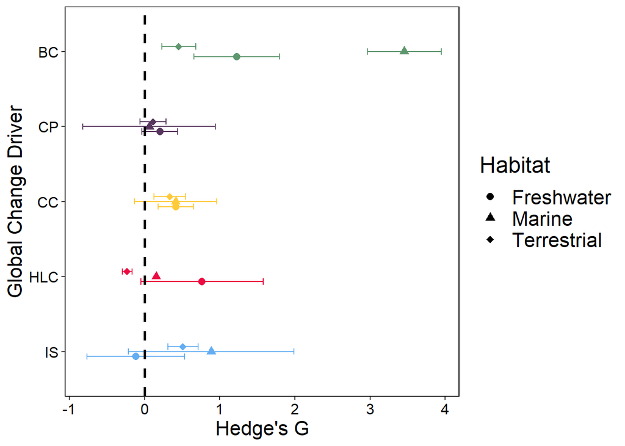

```r
##Set up emmeans reference grid
mHabitatg <- qdrg(object = mHabitatIntro, data = habdat)

mHabitatgem <- emmeans(mHabitatg, ~ Habitat | Global.Change.Driver)

#Only difference is in BC and HLC
pairs((mHabitatgem))
```

### Route

Route (complex or direct) was significantly different for biodiversity change and IS. Very similar patterns to the vector-borne status results, so likely very similar drivers there.

```r
##Number of replicates
nrow(datRoute)
```

```
## [1] 2779
```

```r
mRoute <- rma.mv(SMDH_yi, SMDH_viC,
                  mods = ~ Route + Global.Change.Driver,
                  random = list(~1|Citation.number, ~1|ind_id),
                  data=datRoute, method = "ML")
mRouteIntML <- rma.mv(SMDH_yi, SMDH_viC,
                  mods = ~ Route * Global.Change.Driver,
                  random = list(~1|Citation.number, ~1|ind_id),
                  data=datRoute, method = "ML")
#Difference
anova(mRoute, mRouteIntML)
```

```
##
##         df        AIC        BIC       AICc     logLik     LRT   pval
## Full    12 10073.8866 10144.8970 10074.0008 -5024.9433
## Reduced  8 10085.4316 10132.7719 10085.4842 -5034.7158 19.5450 0.0006
##                   QE
## Full    1258672.4849
## Reduced 1266476.2114
```

```r
mRouteIntro <- rma.mv(SMDH_yi, SMDH_viC,
                      mods = ~ Route * Global.Change.Driver - 1,
                      random = list(~1|Citation.number, ~1|ind_id), data=datRoute)
mRouteIntro <- robust(mRouteIntro, cluster=Citation.number, clubSandwich=TRUE)
mRouteIntro
```

```
##
## Multivariate Meta-Analysis Model (k = 2745; method: REML)
##
## Variance Components:
##
##             estim    sqrt  nlvls  fixed           factor
## sigma^2.1  0.2053  0.4531    916     no  Citation.number
## sigma^2.2  1.4879  1.2198   2745     no           ind_id
##
## Test for Residual Heterogeneity:
## QE(df = 2735) = 1258672.4849, p-val < .0001
##
## Number of estimates:   2745
## Number of clusters:    916
## Estimates per cluster: 1-41 (mean: 3.00, median: 2)
##
## Test of Moderators (coefficients 1:10):¹
## F(df1 = 10, df2 = 163.83) = 9.7332, p-val < .0001
##
## Model Results:
##
##                                      estimate      se¹     tval¹     df¹
## RouteComplex                           1.1282  0.2760    4.0880   21.19
## RouteDirect                            0.5378  0.1146    4.6941   29.19
## Global.Change.DriverCC                -0.7808  0.3123   -2.5000   53.83
## Global.Change.DriverCP                -0.9543  0.3163   -3.0171   34.08
## Global.Change.DriverHLC               -1.3553  0.2864   -4.7318   29.69
## Global.Change.DriverIS                -1.2886  0.3745   -3.4409   22.85
## RouteDirect:Global.Change.DriverCC     0.5744  0.3362    1.7084   89.46
## RouteDirect:Global.Change.DriverCP     0.5974  0.3350    1.7833   60.22
## RouteDirect:Global.Change.DriverHLC    0.6588  0.3156    2.0873   48.93
## RouteDirect:Global.Change.DriverIS     1.4054  0.4046    3.4732   39.37
##                                        pval¹    ci.lb¹    ci.ub¹
## RouteComplex                         0.0005    0.5546    1.7018   ***
## RouteDirect                          <.0001    0.3036    0.7721   ***
## Global.Change.DriverCC               0.0155   -1.4070   -0.1546     *
## Global.Change.DriverCP               0.0048   -1.5971   -0.3116    **
## Global.Change.DriverHLC              <.0001   -1.9405   -0.7701   ***
## Global.Change.DriverIS               0.0022   -2.0636   -0.5136    **
## RouteDirect:Global.Change.DriverCC   0.0910   -0.0936    1.2423     .
## RouteDirect:Global.Change.DriverCP   0.0796   -0.0726    1.2675     .
## RouteDirect:Global.Change.DriverHLC  0.0421    0.0245    1.2930     *
## RouteDirect:Global.Change.DriverIS   0.0013    0.5872    2.2237    **
##
## ---
## Signif. codes:  0 '***' 0.001 '**' 0.01 '*' 0.05 '.' 0.1 ' ' 1
##
## 1) results based on cluster-robust inference (var-cov estimator: CR2,
##    approx t/F-tests and confidence intervals, df: Satterthwaite approx)
```

```
## Global.Change.Driver = BC:
##  contrast         estimate    SE  df z.ratio p.value
##  Complex - Direct  0.59037 0.285 Inf   2.074  0.0381
##
## Global.Change.Driver = CC:
##  contrast         estimate    SE  df z.ratio p.value
##  Complex - Direct  0.01601 0.179 Inf   0.090  0.9287
##
## Global.Change.Driver = CP:
##  contrast         estimate    SE  df z.ratio p.value
##  Complex - Direct -0.00707 0.177 Inf  -0.040  0.9681
##
## Global.Change.Driver = HLC:
##  contrast         estimate    SE  df z.ratio p.value
##  Complex - Direct -0.06838 0.136 Inf  -0.502  0.6160
##
## Global.Change.Driver = IS:
##  contrast         estimate    SE  df z.ratio p.value
##  Complex - Direct -0.81505 0.288 Inf  -2.834  0.0046
```

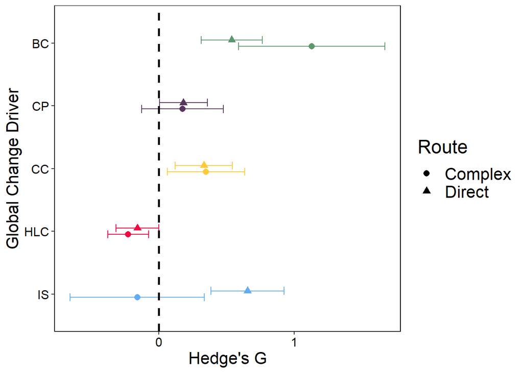

```r
##Set up emmeans reference grid
mRouteIntg <- qdrg(object = mRouteIntro, data = datRoute)

mRouteIntgem <- emmeans(mRouteIntg, ~ Route | Global.Change.Driver)

#Differences in BC and IS
pairs((mRouteIntgem))
```

### Free Living Stages

There was no difference among different types of free living stages in their response to global change drivers.

```r
##Number of replicates
nrow(datFLstage)
```

```
## [1] 2795
```

```r
mStage <- rma.mv(SMDH_yi, SMDH_viC,
                  mods = ~ Free.living.stages + Global.Change.Driver,
                  random = list(~1|Citation.number, ~1|ind_id),
                  data=datFLstage, method = "ML")
mStageIntML <- rma.mv(SMDH_yi, SMDH_viC,
                  mods = ~ Free.living.stages * Global.Change.Driver,
                  random = list(~1|Citation.number, ~1|ind_id),
                  data=datFLstage, method = "ML")
#No Difference
anova(mStage, mStageIntML)
```

```
##
##         df        AIC        BIC       AICc     logLik    LRT   pval
## Full    12 10146.4445 10217.5203 10146.5580 -5061.2222
## Reduced  8 10146.6963 10194.0802 10146.7486 -5065.3481 8.2518 0.0828
##                   QE
## Full    1281126.3430
## Reduced 1284550.8231
```

```r
anova(mStage, btt = 2)
```

```
##
## Test of Moderators (coefficient 2):
## QM(df = 1) = 2.3206, p-val = 0.1277
```

```r
##No difference between free-living and non-free living parasites

mStage <- rma.mv(SMDH_yi, SMDH_viC,
                  mods = ~ Free.living.stages + Global.Change.Driver - 1,
                  random = list(~1|Citation.number, ~1|ind_id),
                  data=datFLstage, method = "REML")
mStagero <- robust(mStage, cluster=Citation.number, clubSandwich=TRUE)
mStagero
```

```
##
## Multivariate Meta-Analysis Model (k = 2760; method: REML)
##
## Variance Components:
##
##             estim    sqrt  nlvls  fixed           factor
## sigma^2.1  0.2053  0.4531    925     no  Citation.number
## sigma^2.2  1.4898  1.2206   2760     no           ind_id
##
## Test for Residual Heterogeneity:
## QE(df = 2754) = 1284550.8231, p-val < .0001
##
## Number of estimates:   2760
## Number of clusters:    925
## Estimates per cluster: 1-41 (mean: 2.98, median: 2)
##
## Test of Moderators (coefficients 1:6):¹
## F(df1 = 6, df2 = 280.31) = 15.1997, p-val < .0001
##
## Model Results:
##
##                          estimate      se¹     tval¹      df¹    pval¹
## Free.living.stagesNo       0.6972  0.1413    4.9338    81.22   <.0001
## Free.living.stagesYes      0.7964  0.1388    5.7364     50.7   <.0001
## Global.Change.DriverCC    -0.4133  0.1622   -2.5489   126.76   0.0120
## Global.Change.DriverCP    -0.6058  0.1579   -3.8363   115.34   0.0002
## Global.Change.DriverHLC   -0.9351  0.1429   -6.5448    79.97   <.0001
## Global.Change.DriverIS    -0.2918  0.1844   -1.5824   109.46   0.1164
##                            ci.lb¹    ci.ub¹
## Free.living.stagesNo      0.4161    0.9784   ***
## Free.living.stagesYes     0.5177    1.0752   ***
## Global.Change.DriverCC   -0.7342   -0.0924     *
## Global.Change.DriverCP   -0.9185   -0.2930   ***
## Global.Change.DriverHLC  -1.2194   -0.6507   ***
## Global.Change.DriverIS   -0.6573    0.0737
##
## ---
## Signif. codes:  0 '***' 0.001 '**' 0.01 '*' 0.05 '.' 0.1 ' ' 1
##
## 1) results based on cluster-robust inference (var-cov estimator: CR2,
##    approx t/F-tests and confidence intervals, df: Satterthwaite approx)
```

```r
mStageg <- qdrg(object = mStagero, data = datFLstage)

mStagegem <- emmeans(mStageg, ~ Free.living.stages)
mStagegem
```

```
##  Free.living.stages emmean     SE  df asymp.LCL asymp.UCL
##  No                  0.248 0.0629 Inf     0.125     0.371
##  Yes                 0.347 0.0470 Inf     0.255     0.439
##
## Results are averaged over the levels of: Global.Change.Driver
## Confidence level used: 0.95
```

### Macroparasites

Parasite size was different for biodiversity change (macroparasites responded more positively to biodiversity loss) and for Habitat Loss/Change (macroparasites responded more negatively to habitat loss/change).

```r
##Number of replicates
nrow(datMacroparasite)
```

```
## [1] 2911
```

```r
mMacro <- rma.mv(SMDH_yi, SMDH_viC,
                  mods = ~ Macroparasite + Global.Change.Driver,
                  random = list(~1|Citation.number, ~1|ind_id),
                  data=datMacroparasite, method = "ML")
mMacroIntML <- rma.mv(SMDH_yi, SMDH_viC,
                  mods = ~ Macroparasite * Global.Change.Driver,
                  random = list(~1|Citation.number, ~1|ind_id),
                  data=datMacroparasite, method = "ML")
#Difference
anova(mMacro, mMacroIntML)
```

```
##
##         df        AIC        BIC       AICc     logLik     LRT   pval
## Full    12 10429.3754 10500.9411 10429.4844 -5202.6877
## Reduced  8 10463.9654 10511.6759 10464.0157 -5223.9827 42.5900 <.0001
##                   QE
## Full    1274162.0007
## Reduced 1279850.2740
```

```r
mMacroInt <- rma.mv(SMDH_yi, SMDH_viC,
                  mods = ~ Macroparasite * Global.Change.Driver - 1,
                  random = list(~1|Citation.number, ~1|ind_id),
                  data=datMacroparasite)
mMacroIntro <- robust(mMacroInt, cluster=Citation.number, clubSandwich=TRUE)
mMacroIntro
```

```
##
## Multivariate Meta-Analysis Model (k = 2875; method: REML)
##
## Variance Components:
##
##             estim    sqrt  nlvls  fixed           factor
## sigma^2.1  0.1732  0.4161    976     no  Citation.number
## sigma^2.2  1.4253  1.1938   2875     no           ind_id
##
## Test for Residual Heterogeneity:
## QE(df = 2865) = 1274162.0007, p-val < .0001
##
## Number of estimates:   2875
## Number of clusters:    976
## Estimates per cluster: 1-41 (mean: 2.95, median: 2)
##
## Test of Moderators (coefficients 1:10):¹
## F(df1 = 10, df2 = 174.61) = 10.1690, p-val < .0001
##
## Model Results:
##
##                                           estimate      se¹     tval¹     df¹
## MacroparasiteNo                             0.4547  0.1014    4.4849    33.6
## MacroparasiteYes                            1.3977  0.2983    4.6848   15.59
## Global.Change.DriverCC                     -0.1996  0.1491   -1.3384   89.94
## Global.Change.DriverCP                     -0.2949  0.1350   -2.1848   77.93
## Global.Change.DriverHLC                    -0.5452  0.1129   -4.8307   60.56
## Global.Change.DriverIS                      0.2356  0.2232    1.0555   73.52
## MacroparasiteYes:Global.Change.DriverCC    -0.7224  0.3457   -2.0896    62.3
## MacroparasiteYes:Global.Change.DriverCP    -0.8875  0.3425   -2.5911      52
## MacroparasiteYes:Global.Change.DriverHLC   -1.1115  0.3095   -3.5909   33.08
## MacroparasiteYes:Global.Change.DriverIS    -1.6740  0.5125   -3.2665   58.65
##                                             pval¹    ci.lb¹    ci.ub¹
## MacroparasiteNo                           <.0001    0.2485    0.6608   ***
## MacroparasiteYes                          0.0003    0.7639    2.0315   ***
## Global.Change.DriverCC                    0.1841   -0.4958    0.0967
## Global.Change.DriverCP                    0.0319   -0.5637   -0.0262     *
## Global.Change.DriverHLC                   <.0001   -0.7710   -0.3195   ***
## Global.Change.DriverIS                    0.2947   -0.2092    0.6803
## MacroparasiteYes:Global.Change.DriverCC   0.0407   -1.4134   -0.0314     *
## MacroparasiteYes:Global.Change.DriverCP   0.0124   -1.5747   -0.2002     *
## MacroparasiteYes:Global.Change.DriverHLC  0.0011   -1.7412   -0.4818    **
## MacroparasiteYes:Global.Change.DriverIS   0.0018   -2.6996   -0.6484    **
##
## ---
## Signif. codes:  0 '***' 0.001 '**' 0.01 '*' 0.05 '.' 0.1 ' ' 1
##
## 1) results based on cluster-robust inference (var-cov estimator: CR2,
##    approx t/F-tests and confidence intervals, df: Satterthwaite approx)
```

```
## Global.Change.Driver = BC:
##  contrast estimate    SE  df z.ratio p.value
##  No - Yes  -0.9431 0.303 Inf  -3.116  0.0018
##
## Global.Change.Driver = CC:
##  contrast estimate    SE  df z.ratio p.value
##  No - Yes  -0.2207 0.167 Inf  -1.321  0.1865
##
## Global.Change.Driver = CP:
##  contrast estimate    SE  df z.ratio p.value
##  No - Yes  -0.0556 0.160 Inf  -0.347  0.7285
##
## Global.Change.Driver = HLC:
##  contrast estimate    SE  df z.ratio p.value
##  No - Yes   0.1685 0.065 Inf   2.592  0.0095
##
## Global.Change.Driver = IS:
##  contrast estimate    SE  df z.ratio p.value
##  No - Yes   0.7310 0.414 Inf   1.767  0.0772
```

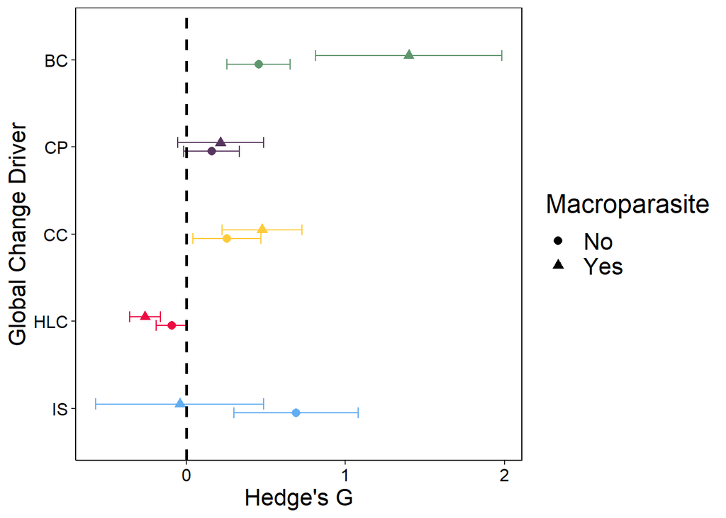

```r
##Set up emmeans reference grid
mMacroIntg <- qdrg(object = mMacroIntro, data = datMacroparasite)

mMacroIntgem <- emmeans(mMacroIntg, ~ Macroparasite | Global.Change.Driver)

#Differences in BC and HLC
pairs((mMacroIntgem))
```

### Host Thermy

We see a slight difference in disease response between ecto- and endo- thermic hosts for biodiversity change and habitat loss/change. For biodiversity change, this suggests that changes in biodiversity will increase disease more in ectothermic hosts than in endothermic hosts. And for HLC, it suggests the opposite (disease decreasing in endothermic hosts more than ectothermic hosts).

```r
##Number of replicates
nrow(datHostThermy)
```

```
## [1] 2937
```

```r
mThermy <- rma.mv(SMDH_yi, SMDH_viC,
                  mods = ~ Ectothermic.host + Global.Change.Driver,
                  random = list(~1|Citation.number, ~1|ind_id),
                  data=datHostThermy, method = "ML")
mThermyIntML <- rma.mv(SMDH_yi, SMDH_viC,
                  mods = ~ Ectothermic.host * Global.Change.Driver,
                  random = list(~1|Citation.number, ~1|ind_id),
                  data=datHostThermy, method = "ML")
#Difference!
anova(mThermy, mThermyIntML)
```

```
##
##         df        AIC        BIC       AICc     logLik     LRT   pval
## Full    12 10532.6846 10604.3583 10532.7926 -5254.3423
## Reduced  8 10538.8701 10586.6526 10538.9199 -5261.4351 14.1855 0.0067
##                   QE
## Full    1301296.1698
## Reduced 1305520.6119
```

```r
mThermyInt <- rma.mv(SMDH_yi, SMDH_viC,
                  mods = ~ Ectothermic.host * Global.Change.Driver-1,
                  random = list(~1|Citation.number, ~1|ind_id),
                  data=datHostThermy)
mThermyIntro <- robust(mThermyInt, cluster=Citation.number, clubSandwich=TRUE)
mThermyIntro
```

```
##
## Multivariate Meta-Analysis Model (k = 2901; method: REML)
##
## Variance Components:
##
##             estim    sqrt  nlvls  fixed           factor
## sigma^2.1  0.1675  0.4093    987     no  Citation.number
## sigma^2.2  1.4303  1.1960   2901     no           ind_id
##
## Test for Residual Heterogeneity:
## QE(df = 2891) = 1301296.1698, p-val < .0001
##
## Number of estimates:   2901
## Number of clusters:    987
## Estimates per cluster: 1-41 (mean: 2.94, median: 2)
##
## Test of Moderators (coefficients 1:10):¹
## F(df1 = 10, df2 = 103.17) = 11.0502, p-val < .0001
##
## Model Results:
##
##                                              estimate      se¹     tval¹
## Ectothermic.hostNo                             0.1925  0.1245    1.5457
## Ectothermic.hostYes                            0.9861  0.1656    5.9531
## Global.Change.DriverCC                         0.1864  0.1829    1.0194
## Global.Change.DriverCP                         0.3070  0.3783    0.8114
## Global.Change.DriverHLC                       -0.4233  0.1298   -3.2626
## Global.Change.DriverIS                        -0.1293  0.3344   -0.3866
## Ectothermic.hostYes:Global.Change.DriverCC    -0.8244  0.2616   -3.1516
## Ectothermic.hostYes:Global.Change.DriverCP    -1.1643  0.4151   -2.8049
## Ectothermic.hostYes:Global.Change.DriverHLC   -0.4630  0.2795   -1.6570
## Ectothermic.hostYes:Global.Change.DriverIS    -0.3307  0.3867   -0.8551
##                                                 df¹    pval¹    ci.lb¹
## Ectothermic.hostNo                            16.1   0.1416   -0.0714
## Ectothermic.hostYes                          32.63   <.0001    0.6489
## Global.Change.DriverCC                       34.07   0.3152   -0.1852
## Global.Change.DriverCP                        7.06   0.4436   -0.5861
## Global.Change.DriverHLC                      18.33   0.0042   -0.6956
## Global.Change.DriverIS                       24.68   0.7024   -0.8185
## Ectothermic.hostYes:Global.Change.DriverCC   63.74   0.0025   -1.3471
## Ectothermic.hostYes:Global.Change.DriverCP    9.08   0.0204   -2.1020
## Ectothermic.hostYes:Global.Change.DriverHLC  50.02   0.1038   -1.0243
## Ectothermic.hostYes:Global.Change.DriverIS   35.39   0.3983   -1.1155
##                                                ci.ub¹
## Ectothermic.hostNo                            0.4563
## Ectothermic.hostYes                           1.3232   ***
## Global.Change.DriverCC                        0.5581
## Global.Change.DriverCP                        1.2000
## Global.Change.DriverHLC                      -0.1511    **
## Global.Change.DriverIS                        0.5599
## Ectothermic.hostYes:Global.Change.DriverCC   -0.3018    **
## Ectothermic.hostYes:Global.Change.DriverCP   -0.2266     *
## Ectothermic.hostYes:Global.Change.DriverHLC   0.0982
## Ectothermic.hostYes:Global.Change.DriverIS    0.4541
##
## ---
## Signif. codes:  0 '***' 0.001 '**' 0.01 '*' 0.05 '.' 0.1 ' ' 1
##
## 1) results based on cluster-robust inference (var-cov estimator: CR2,
##    approx t/F-tests and confidence intervals, df: Satterthwaite approx)
```

```
## Global.Change.Driver = BC:
##  contrast estimate    SE  df z.ratio p.value
##  No - Yes  -0.7936 0.198 Inf  -4.011  0.0001
##
## Global.Change.Driver = CC:
##  contrast estimate    SE  df z.ratio p.value
##  No - Yes   0.0308 0.171 Inf   0.180  0.8570
##
## Global.Change.Driver = CP:
##  contrast estimate    SE  df z.ratio p.value
##  No - Yes   0.3707 0.365 Inf   1.015  0.3103
##
## Global.Change.Driver = HLC:
##  contrast estimate    SE  df z.ratio p.value
##  No - Yes  -0.3306 0.197 Inf  -1.675  0.0940
##
## Global.Change.Driver = IS:
##  contrast estimate    SE  df z.ratio p.value
##  No - Yes  -0.4629 0.332 Inf  -1.393  0.1636
```

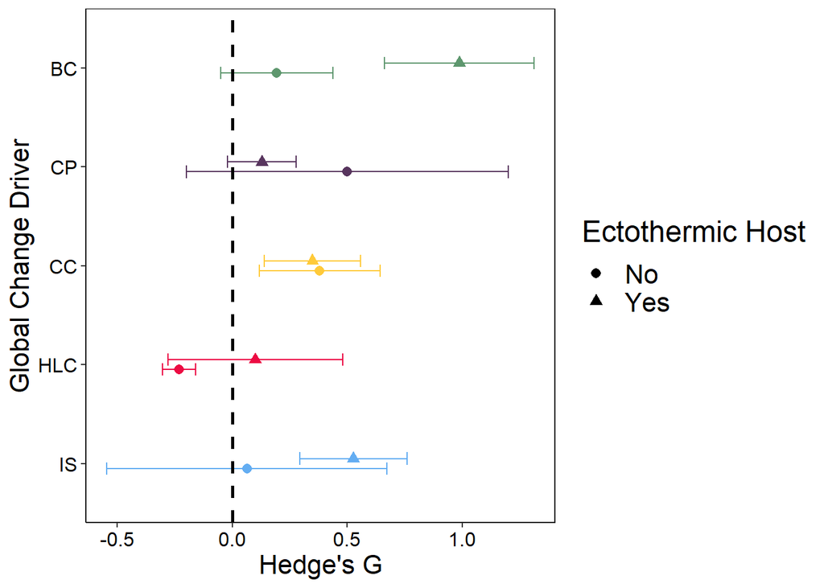

```r
##Set up emmeans reference grid
mThermyIntg <- qdrg(object = mThermyIntro, data = datHostThermy)

mThermyIntgem <- emmeans(mThermyIntg, ~ Ectothermic.host | Global.Change.Driver)

#Differences in BC and HLC
pairs((mThermyIntgem))
```

### Zoonotic

We see no difference between of Zoonotic/non-zoonotic diseases either main or interactive effects.

```r
##Number of replicates
nrow(datZoonotic)
```

```
## [1] 2789
```

```r
mZoo <- rma.mv(SMDH_yi, SMDH_viC,
                  mods = ~ Zoonotic + Global.Change.Driver,
                  random = list(~1|Citation.number, ~1|ind_id),
                  data=datZoonotic, method = "ML")
mZooIntML <- rma.mv(SMDH_yi, SMDH_viC,
                  mods = ~ Zoonotic * Global.Change.Driver,
                  random = list(~1|Citation.number, ~1|ind_id),
                  data=datZoonotic, method = "ML")
#no difference
anova(mZoo, mZooIntML)
```

```
##
##         df        AIC        BIC       AICc     logLik    LRT   pval
## Full    12 10118.4013 10189.4511 10118.5152 -5047.2007
## Reduced  8 10115.5793 10162.9458 10115.6318 -5049.7897 5.1780 0.2695
##                   QE
## Full    1243605.9975
## Reduced 1285386.0330
```

```r
mZooInt <- rma.mv(SMDH_yi, SMDH_viC,
                  mods = ~ Zoonotic + Global.Change.Driver-1,
                  random = list(~1|Citation.number, ~1|ind_id),
                  data=datZoonotic)
mZooIntro <- robust(mZooInt, cluster=Citation.number, clubSandwich=TRUE)
mZooIntro
```

```
##
## Multivariate Meta-Analysis Model (k = 2754; method: REML)
##
## Variance Components:
##
##             estim    sqrt  nlvls  fixed           factor
## sigma^2.1  0.2068  0.4548    909     no  Citation.number
## sigma^2.2  1.4857  1.2189   2754     no           ind_id
##
## Test for Residual Heterogeneity:
## QE(df = 2748) = 1285386.0330, p-val < .0001
##
## Number of estimates:   2754
## Number of clusters:    909
## Estimates per cluster: 1-41 (mean: 3.03, median: 2)
##
## Test of Moderators (coefficients 1:6):¹
## F(df1 = 6, df2 = 283.03) = 14.8672, p-val < .0001
##
## Model Results:
##
##                          estimate      se¹     tval¹      df¹    pval¹
## ZoonoticNo                 0.7610  0.1405    5.4175    51.05   <.0001
## ZoonoticYes                0.7906  0.1622    4.8748    81.66   <.0001
## Global.Change.DriverCC    -0.4065  0.1623   -2.5053   123.85   0.0135
## Global.Change.DriverCP    -0.6078  0.1590   -3.8215   115.42   0.0002
## Global.Change.DriverHLC   -0.9666  0.1503   -6.4309    81.56   <.0001
## Global.Change.DriverIS    -0.3036  0.1827   -1.6618   109.07   0.0994
##                            ci.lb¹    ci.ub¹
## ZoonoticNo                0.4790    1.0430   ***
## ZoonoticYes               0.4679    1.1132   ***
## Global.Change.DriverCC   -0.7276   -0.0853     *
## Global.Change.DriverCP   -0.9228   -0.2928   ***
## Global.Change.DriverHLC  -1.2656   -0.6676   ***
## Global.Change.DriverIS   -0.6657    0.0585     .
##
## ---
## Signif. codes:  0 '***' 0.001 '**' 0.01 '*' 0.05 '.' 0.1 ' ' 1
##
## 1) results based on cluster-robust inference (var-cov estimator: CR2,
##    approx t/F-tests and confidence intervals, df: Satterthwaite approx)
```

```r
##Set up emmeans reference grid
mZooIntg <- qdrg(object = mZooIntro, data = datZoonotic)

mZooIntgem <- emmeans(mZooIntg, ~ Zoonotic)

#Differences in BC and HLC
pairs((mZooIntgem))
```

```
##  contrast estimate    SE  df z.ratio p.value
##  No - Yes  -0.0296 0.107 Inf  -0.277  0.7822
##
## Results are averaged over the levels of: Global.Change.Driver
```

### Secondary analyses

#### Zoonotic diseases

For zoonotic diseases, whether the response of these diseases in humans and non-human animals to global change drivers is consistent (i.e., not significantly different) may provide clarity into emerging infectious diseases and pandemic risk. Here, we show no interaction between human and non-human endpoints and the global change drivers. But, there is a significant difference between human and non-human endpoints in their responses across global change drivers. Specifically, disease in non-humans responds more positively to global change drivers than disease in humans, such that the response disease in non-humans is consistently more positive (closer to zero if response of human disease is negative) than disease in humans.

```r
zoodat1 <- fulldat2 %>%
  filter(Zoonotic == "Yes")

nrow(zoodat1)
```

```
## [1] 777
```

```r
mZooHum <- rma.mv(SMDH_yi, SMDH_viC,
                  mods = ~ humanendpoint + Global.Change.Driver,
                  random = list(~1|Citation.number, ~1|ind_id),
                  data=zoodat1, method = "ML")
mZooHumIntML <- rma.mv(SMDH_yi, SMDH_viC,
                  mods = ~ humanendpoint * Global.Change.Driver,
                  random = list(~1|Citation.number, ~1|ind_id),
                  data=zoodat1, method = "ML")
#no difference
anova(mZooHum, mZooHumIntML)
```

```
##
##         df       AIC       BIC      AICc     logLik    LRT   pval         QE
## Full    11 2633.5482 2684.5292 2633.9007 -1305.7741               61174.6588
## Reduced  8 2629.8342 2666.9112 2630.0257 -1306.9171 2.2859 0.5152 70626.0823
```

```r
mZooHum <- rma.mv(SMDH_yi, SMDH_viC,
                  mods = ~ humanendpoint + Global.Change.Driver - 1,
                  random = list(~1|Citation.number, ~1|ind_id),
                  data=zoodat1, method = "REML")
mZooHumro <- robust(mZooHum, cluster=Citation.number, clubSandwich=TRUE)
mZooHumro
```

```
##
## Multivariate Meta-Analysis Model (k = 761; method: REML)
##
## Variance Components:
##
##             estim    sqrt  nlvls  fixed           factor
## sigma^2.1  1.7302  1.3154    371     no  Citation.number
## sigma^2.2  0.3655  0.6046    761     no           ind_id
##
## Test for Residual Heterogeneity:
## QE(df = 755) = 70626.0823, p-val < .0001
##
## Number of estimates:   761
## Number of clusters:    371
## Estimates per cluster: 1-14 (mean: 2.05, median: 1)
##
## Test of Moderators (coefficients 1:6):¹
## F(df1 = 6, df2 = 29.31) = 2.6846, p-val = 0.0336
##
## Model Results:
##
##                          estimate      se¹     tval¹     df¹    pval¹    ci.lb¹
## humanendpointNo            0.5671  0.2160    2.6255   25.96   0.0143    0.1231
## humanendpointYes           0.2753  0.2427    1.1341   35.61   0.2643   -0.2172
## Global.Change.DriverCC     0.0962  0.2843    0.3383   58.79   0.7364   -0.4727
## Global.Change.DriverCP     0.3658  0.9514    0.3845    3.78   0.7213   -2.3382
## Global.Change.DriverHLC   -0.5130  0.2269   -2.2609   33.55   0.0304   -0.9744
## Global.Change.DriverIS    -0.7906  0.4620   -1.7113    9.22   0.1204   -1.8318
##                            ci.ub¹
## humanendpointNo           1.0111   *
## humanendpointYes          0.7678
## Global.Change.DriverCC    0.6650
## Global.Change.DriverCP    3.0698
## Global.Change.DriverHLC  -0.0516   *
## Global.Change.DriverIS    0.2507
##
## ---
## Signif. codes:  0 '***' 0.001 '**' 0.01 '*' 0.05 '.' 0.1 ' ' 1
##
## 1) results based on cluster-robust inference (var-cov estimator: CR2,
##    approx t/F-tests and confidence intervals, df: Satterthwaite approx)
```

```r
##Set up emmeans reference grid
mZooHumg <- qdrg(object = mZooHumro, data = zoodat1)

mZooHumgem <- emmeans(mZooHumg, ~ humanendpoint)

#Difference between human and non-human endpoints
pairs((mZooHumgem))
```

```
##  contrast estimate    SE  df z.ratio p.value
##  No - Yes    0.292 0.127 Inf   2.299  0.0215
##
## Results are averaged over the levels of: Global.Change.Driver
```

#### Wild-life vs. domestic endpoints - animals only

```r
wddat <- fulldat2 %>% filter(!is.na(domesticatedanimalendpoint))

nrow(wddat)
```

```
## [1] 841
```

```r
mwdanML <- rma.mv(SMDH_yi, SMDH_viC,
                  mods = ~ domesticatedanimalendpoint + Global.Change.Driver,
                  random = list(~1|Citation.number, ~1|ind_id),
                  data=wddat, method = "ML")
mwdanIntML <- rma.mv(SMDH_yi, SMDH_viC,
                  mods = ~ domesticatedanimalendpoint * Global.Change.Driver,
                  random = list(~1|Citation.number, ~1|ind_id),
                  data=wddat, method = "ML")
#no difference
anova(mwdanML, mwdanIntML)
```

```
##
##         df       AIC       BIC      AICc     logLik    LRT   pval         QE
## Full    12 3143.0322 3199.7614 3143.4118 -1559.5161               63670.5089
## Reduced  8 3137.4607 3175.2802 3137.6350 -1560.7304 2.4285 0.6575 68976.6725
```

```r
mwda <- rma.mv(SMDH_yi, SMDH_viC,
                  mods = ~ domesticatedanimalendpoint + Global.Change.Driver - 1,
                  random = list(~1|Citation.number, ~1|ind_id),
                  data=wddat, method = "REML")
mwdaro <- robust(mwda, cluster=Citation.number, clubSandwich=TRUE)
mwdaro
```

```
##
## Multivariate Meta-Analysis Model (k = 835; method: REML)
##
## Variance Components:
##
##             estim    sqrt  nlvls  fixed           factor
## sigma^2.1  0.1442  0.3797    335     no  Citation.number
## sigma^2.2  1.4792  1.2162    835     no           ind_id
##
## Test for Residual Heterogeneity:
## QE(df = 829) = 68976.6725, p-val < .0001
##
## Number of estimates:   835
## Number of clusters:    335
## Estimates per cluster: 1-24 (mean: 2.49, median: 1)
##
## Test of Moderators (coefficients 1:6):¹
## F(df1 = 6, df2 = 86.65) = 4.5831, p-val = 0.0004
##
## Model Results:
##
##                                estimate      se¹     tval¹     df¹    pval¹
## domesticatedanimalendpointNo     0.2106  0.1298    1.6229   17.86   0.1221
## domesticatedanimalendpointYes   -0.0223  0.1514   -0.1476    33.7   0.8836
## Global.Change.DriverCC           0.3775  0.2379    1.5868   41.04   0.1202
## Global.Change.DriverCP           0.1604  0.2610    0.6146   37.82   0.5425
## Global.Change.DriverHLC         -0.2542  0.1457   -1.7448   25.14   0.0932
## Global.Change.DriverIS           0.0401  0.4448    0.0901   38.22   0.9287
##                                  ci.lb¹   ci.ub¹
## domesticatedanimalendpointNo   -0.0622   0.4834
## domesticatedanimalendpointYes  -0.3302   0.2855
## Global.Change.DriverCC         -0.1029   0.8580
## Global.Change.DriverCP         -0.3681   0.6889
## Global.Change.DriverHLC        -0.5541   0.0458   .
## Global.Change.DriverIS         -0.8601   0.9403
##
## ---
## Signif. codes:  0 '***' 0.001 '**' 0.01 '*' 0.05 '.' 0.1 ' ' 1
##
## 1) results based on cluster-robust inference (var-cov estimator: CR2,
##    approx t/F-tests and confidence intervals, df: Satterthwaite approx)
```

```r
##Set up emmeans reference grid
mwdag <- qdrg(object = mwdaro, data = wddat)

mwdagem <- emmeans(mwdag, ~ domesticatedanimalendpoint)

#Difference between wild and domesticated animal endpoints
pairs((mwdagem))
```

```
##  contrast estimate     SE  df z.ratio p.value
##  No - Yes    0.233 0.0884 Inf   2.636  0.0084
##
## Results are averaged over the levels of: Global.Change.Driver
```

#### HLC supplemental analyses

Within HLC, we are testing whether enemy types respond differently to urbanization. Additionally, we are testing whether the reference land-use (rural, peri-urban, natural, or urbanization gradient) for urbanization influences the magnitude/direction of the effect size. Finally, we are testing whether for deforestation and fragmentation, the treatment (e.g., agriculture vs. clearcut/regrowth for deforestation and fragmentation gradient or high/low fragmentation for forest fragmentation) influences the magnitude/direction of the effect size.

```r
urbdat <- fulldat2 %>% filter(Effect == "Urbanization")


nrow(zoodat1)
```

```
## [1] 777
```

```r
mUrb <- rma.mv(SMDH_yi, SMDH_viC,
                  mods = ~ Enemy.type - 1,
                  random = list(~1|Citation.number, ~1|ind_id),
                  data=urbdat, method = "REML")
mUrbro <- robust(mUrb, cluster=Citation.number, clubSandwich=TRUE)
mUrbro
```

```
##
## Multivariate Meta-Analysis Model (k = 1227; method: REML)
##
## Variance Components:
##
##             estim    sqrt  nlvls  fixed           factor
## sigma^2.1  0.0523  0.2287    435     no  Citation.number
## sigma^2.2  2.0115  1.4183   1227     no           ind_id
##
## Test for Residual Heterogeneity:
## QE(df = 1221) = 281726.0707, p-val < .0001
##
## Number of estimates:   1227
## Number of clusters:    435
## Estimates per cluster: 1-36 (mean: 2.82, median: 1)
##
## Test of Moderators (coefficients 1:6):¹
## F(df1 = 6, df2 = 53.33) = 5.5982, p-val = 0.0001
##
## Model Results:
##
##                      estimate      se¹     tval¹     df¹    pval¹    ci.lb¹
## Enemy.typeArthropod   -0.3257  0.1068   -3.0504   20.04   0.0063   -0.5485
## Enemy.typeBacteria    -0.0519  0.0855   -0.6076   41.91   0.5468   -0.2245
## Enemy.typeFungi       -0.5199  0.2997   -1.7348    6.16   0.1322   -1.2485
## Enemy.typeHelminth    -0.3649  0.0906   -4.0274   95.42   0.0001   -0.5448
## Enemy.typeProtist     -0.1456  0.0499   -2.9159   103.5   0.0043   -0.2447
## Enemy.typeVirus        0.0690  0.0674    1.0238   24.61   0.3159   -0.0699
##                        ci.ub¹
## Enemy.typeArthropod  -0.1030    **
## Enemy.typeBacteria    0.1206
## Enemy.typeFungi       0.2088
## Enemy.typeHelminth   -0.1850   ***
## Enemy.typeProtist    -0.0466    **
## Enemy.typeVirus       0.2080
##
## ---
## Signif. codes:  0 '***' 0.001 '**' 0.01 '*' 0.05 '.' 0.1 ' ' 1
##
## 1) results based on cluster-robust inference (var-cov estimator: CR2,
##    approx t/F-tests and confidence intervals, df: Satterthwaite approx)
```

```r
##Set up emmeans reference grid
mUrbg <- qdrg(object = mUrbro, data = urbdat)

mUrbgem <- emmeans(mUrbg, ~ Enemy.type)

#Difference between human and non-human endpoints
pairs((mUrbgem))
```

```
##  contrast             estimate     SE  df z.ratio p.value
##  Arthropod - Bacteria  -0.2738 0.1355 Inf  -2.021  0.3304
##  Arthropod - Fungi      0.1941 0.3133 Inf   0.619  0.9896
##  Arthropod - Helminth   0.0392 0.1421 Inf   0.276  0.9998
##  Arthropod - Protist   -0.1801 0.1170 Inf  -1.540  0.6385
##  Arthropod - Virus     -0.3948 0.1256 Inf  -3.142  0.0208
##  Bacteria - Fungi       0.4679 0.3081 Inf   1.518  0.6523
##  Bacteria - Helminth    0.3130 0.1126 Inf   2.779  0.0608
##  Bacteria - Protist     0.0937 0.0973 Inf   0.963  0.9295
##  Bacteria - Virus      -0.1210 0.1039 Inf  -1.164  0.8541
##  Fungi - Helminth      -0.1549 0.3128 Inf  -0.495  0.9964
##  Fungi - Protist       -0.3742 0.3033 Inf  -1.234  0.8204
##  Fungi - Virus         -0.5889 0.2952 Inf  -1.995  0.3450
##  Helminth - Protist    -0.2193 0.0989 Inf  -2.218  0.2293
##  Helminth - Virus      -0.4339 0.1119 Inf  -3.877  0.0015
##  Protist - Virus       -0.2147 0.0840 Inf  -2.555  0.1087
##
## P value adjustment: tukey method for comparing a family of 6 estimates
```

```r
emmeans:::cld.emmGrid(mUrbgem)
```

```
##  Enemy.type  emmean     SE  df asymp.LCL asymp.UCL .group
##  Fungi      -0.5199 0.2997 Inf   -1.1072    0.0675  12
##  Helminth   -0.3649 0.0906 Inf   -0.5425   -0.1873  1
##  Arthropod  -0.3257 0.1068 Inf   -0.5350   -0.1164  1
##  Protist    -0.1456 0.0499 Inf   -0.2435   -0.0477  12
##  Bacteria   -0.0519 0.0855 Inf   -0.2195    0.1156  12
##  Virus       0.0690 0.0674 Inf   -0.0631    0.2012   2
##
## Confidence level used: 0.95
## P value adjustment: tukey method for comparing a family of 6 estimates
## significance level used: alpha = 0.05
## NOTE: If two or more means share the same grouping symbol,
##       then we cannot show them to be different.
##       But we also did not show them to be the same.
```

```r
### reference condition

mUrb_c <- rma.mv(SMDH_yi, SMDH_viC,
                  mods = ~ Urb_control - 1,
                  random = list(~1|Citation.number, ~1|ind_id),
                  data=urbdat, method = "REML")
mUrb_cro <- robust(mUrb_c, cluster=Citation.number, clubSandwich=TRUE)
mUrb_cro
```

```
##
## Multivariate Meta-Analysis Model (k = 1264; method: REML)
##
## Variance Components:
##
##             estim    sqrt  nlvls  fixed           factor
## sigma^2.1  0.0538  0.2320    461     no  Citation.number
## sigma^2.2  1.9580  1.3993   1264     no           ind_id
##
## Test for Residual Heterogeneity:
## QE(df = 1260) = 321924.7916, p-val < .0001
##
## Number of estimates:   1264
## Number of clusters:    461
## Estimates per cluster: 1-36 (mean: 2.74, median: 1)
##
## Test of Moderators (coefficients 1:4):¹
## F(df1 = 4, df2 = 33.91) = 7.5703, p-val = 0.0002
##
## Model Results:
##
##                        estimate      se¹     tval¹      df¹    pval¹    ci.lb¹
## Urb_controlGradient      0.0346  0.1658    0.2089     9.38   0.8390   -0.3381
## Urb_controlNatural       0.0445  0.1975    0.2252    13.38   0.8252   -0.3809
## Urb_controlPeri-urban   -0.3430  0.1112   -3.0848    12.04   0.0094   -0.5851
## Urb_controlRural        -0.2412  0.0498   -4.8440   182.75   <.0001   -0.3394
##                          ci.ub¹
## Urb_controlGradient     0.4074
## Urb_controlNatural      0.4699
## Urb_controlPeri-urban  -0.1008    **
## Urb_controlRural       -0.1429   ***
##
## ---
## Signif. codes:  0 '***' 0.001 '**' 0.01 '*' 0.05 '.' 0.1 ' ' 1
##
## 1) results based on cluster-robust inference (var-cov estimator: CR2,
##    approx t/F-tests and confidence intervals, df: Satterthwaite approx)
```

```r
##Set up emmeans reference grid
mUrb_cg <- qdrg(object = mUrb_cro, data = urbdat)

mUrb_cem <- emmeans(mUrb_cg, ~ Urb_control)

#Difference between human and non-human endpoints
pairs((mUrb_cem))
```

```
##  contrast                estimate    SE  df z.ratio p.value
##  Gradient - Natural      -0.00983 0.258 Inf  -0.038  1.0000
##  Gradient - (Peri-urban)  0.37763 0.200 Inf   1.892  0.2315
##  Gradient - Rural         0.27582 0.173 Inf   1.593  0.3824
##  Natural - (Peri-urban)   0.38746 0.227 Inf   1.710  0.3185
##  Natural - Rural          0.28565 0.202 Inf   1.414  0.4907
##  (Peri-urban) - Rural    -0.10181 0.121 Inf  -0.838  0.8364
##
## P value adjustment: tukey method for comparing a family of 4 estimates
```

```r
##deforestation/fragmentation
#clearcut/natural is anything but agriculture; e.g., clearcut and let regrow, clearcut and open, clearcut and park, etc.
#gradient is size gradient, fragment is large/continuous forest patch to small patch
def_fragdat <- fulldat2 %>% filter(Effect %in% c("Deforestation", "Forest Fragmentation"))

mdeff <- rma.mv(SMDH_yi, SMDH_viC,
                  mods = ~ DefFrag_treat - 1,
                  random = list(~1|Citation.number, ~1|ind_id),
                  data=def_fragdat, method = "REML")
mdeffro <- robust(mdeff, cluster=Citation.number, clubSandwich=TRUE)
mdeffro
```

```
##
## Multivariate Meta-Analysis Model (k = 159; method: REML)
##
## Variance Components:
##
##             estim    sqrt  nlvls  fixed           factor
## sigma^2.1  0.0522  0.2285     52     no  Citation.number
## sigma^2.2  0.1543  0.3928    159     no           ind_id
##
## Test for Residual Heterogeneity:
## QE(df = 155) = 446.2211, p-val < .0001
##
## Number of estimates:   159
## Number of clusters:    52
## Estimates per cluster: 1-24 (mean: 3.06, median: 2)
##
## Test of Moderators (coefficients 1:4):¹
## F(df1 = 4, df2 = 12.21) = 2.2978, p-val = 0.1177
##
## Model Results:
##
##                                 estimate      se¹     tval¹     df¹    pval¹
## DefFrag_treatAgriculture         -0.1049  0.1012   -1.0369   10.45   0.3232
## DefFrag_treatClearcut/Regrowth    0.3967  0.2592    1.5306    5.58   0.1804
## DefFrag_treatFragment             0.2524  0.1205    2.0938    9.56   0.0640
## DefFrag_treatGradient            -0.2168  0.1140   -1.9015     3.6   0.1378
##                                   ci.lb¹   ci.ub¹
## DefFrag_treatAgriculture        -0.3291   0.1193
## DefFrag_treatClearcut/Regrowth  -0.2492   1.0427
## DefFrag_treatFragment           -0.0179   0.5226   .
## DefFrag_treatGradient           -0.5477   0.1140
##
## ---
## Signif. codes:  0 '***' 0.001 '**' 0.01 '*' 0.05 '.' 0.1 ' ' 1
##
## 1) results based on cluster-robust inference (var-cov estimator: CR2,
##    approx t/F-tests and confidence intervals, df: Satterthwaite approx)
```

```r
##Set up emmeans reference grid
mdeffg <- qdrg(object = mdeffro, data = def_fragdat)

mdeffgem <- emmeans(mdeffg, ~ DefFrag_treat)

#Difference between treatments within fragmentation, but not deforestation
contrast(mdeffgem, list(Def = c(-1,1,0,0),
                        Frag = c(0,0,-1,1)))
```

```
##  contrast estimate    SE  df z.ratio p.value
##  Def         0.502 0.277 Inf   1.809  0.0705
##  Frag       -0.469 0.166 Inf  -2.828  0.0047
```

```r
datfig_urb <- data.frame(emmeans(mUrbg, ~ Enemy.type))

#make the plot
fig_urbe <- ggplot(datfig_urb, aes(x = Enemy.type,
                        y=emmean,
                        color = Enemy.type)) +            #subtract 2 to adjust range of response
  geom_point(position = position_dodge(width = 0.2),
             size = 2.5) +                               #plot points
  geom_errorbar(aes(ymin = asymp.LCL,        #include error bars
                    ymax = asymp.UCL),
                width=0.25,
                position = position_dodge(width = 0.2)) +                   #adjust width of bar
  # scale_y_continuous(limits = c(0,1.05),      #change limits of Y axis
  #                    breaks = c(0,0.5,1))+      #set Y axis breaks
  geom_hline(yintercept = 0,                   #make a reference line at 0
             linetype = "dashed",
             color = "black",
             size = 1) +
  # scale_shape_manual(values = c(16,17),
  #                    name = "Human Endpoint")+
  xlab("Enemy taxa") +               #relabel X and Y axes
  ylab("Hedge's G") +
  coord_flip()+
  theme_JR()+
  theme(legend.position = 'none')

# ggsave("./Figures/GCDurbanenemy.tiff",
#        dpi = 300,
#        width = 6.5,
#        height = 4.65,
#        units = "in")


datfig_urbc <- data.frame(emmeans(mUrb_cg, ~ Urb_control))
levels(datfig_urbc$Urb_control)[1] = "Urban Gradient"

#make the plot
fig_urbc <- ggplot(datfig_urbc, aes(x = Urb_control,
                        y=emmean,
                        color = Urb_control)) +            #subtract 2 to adjust range of response
  geom_point(position = position_dodge(width = 0.2),
             size = 2.5) +                               #plot points
  geom_errorbar(aes(ymin = asymp.LCL,        #include error bars
                    ymax = asymp.UCL),
                width=0.25,
                position = position_dodge(width = 0.2)) +                   #adjust width of bar
  # scale_y_continuous(limits = c(0,1.05),      #change limits of Y axis
  #                    breaks = c(0,0.5,1))+      #set Y axis breaks
  geom_hline(yintercept = 0,                   #make a reference line at 0
             linetype = "dashed",
             color = "black",
             size = 1) +
  # scale_shape_manual(values = c(16,17),
  #                    name = "Human Endpoint")+
  xlab("Urbanization reference land-use") +               #relabel X and Y axes
  ylab("Hedge's G") +
  coord_flip()+
  theme_JR()+
  theme(legend.position = 'none')

# ggsave("./Figures/GCDfigurban.tiff",
#        dpi = 300,
#        width = 6.5,
#        height = 4.65,
#        units = "in")

datfig_deffc <- data.frame(emmeans(mdeffg, ~ DefFrag_treat))
levels(datfig_deffc$DefFrag_treat)[3] = "High/Low Fragmentation"
levels(datfig_deffc$DefFrag_treat)[4] = "Continuous Gradient"
#make the plot
fig_deffc <- ggplot(datfig_deffc, aes(x = DefFrag_treat,
                        y=emmean,
                        color = DefFrag_treat)) +            #subtract 2 to adjust range of response
  geom_point(position = position_dodge(width = 0.2),
             size = 2.5) +                               #plot points
  geom_errorbar(aes(ymin = asymp.LCL,        #include error bars
                    ymax = asymp.UCL),
                width=0.25,
                position = position_dodge(width = 0.2)) +                   #adjust width of bar
  # scale_y_continuous(limits = c(0,1.05),      #change limits of Y axis
  #                    breaks = c(0,0.5,1))+      #set Y axis breaks
  geom_hline(yintercept = 0,                   #make a reference line at 0
             linetype = "dashed",
             color = "black",
             size = 1) +
  geom_vline(xintercept = 2.5,                   #make a reference line at 0
             linetype = "solid",
             color = "black") +
  # scale_shape_manual(values = c(16,17),
  #                    name = "Human Endpoint")+
  xlab("Treatment land-use") +               #relabel X and Y axes
  ylab("Hedge's G") +
  coord_flip()+
  theme_JR()+
  theme(legend.position = 'none')

# ggsave("./Figures/GCDDefFrag_treat.tiff",
#        dpi = 300,
#        width = 6.5,
#        height = 4.65,
#        units = "in")
```